# Week 10: ANOVA Understanding Contrast and Shrinkage

Joshua Goldberg

December, 06 2018

```
##
## Kruschke, J. K. (2015). Doing Bayesian Data Analysis, Second Edition:
## A Tutorial with R, JAGS, and Stan. Academic Press / Elsevier.
```

# 1 Exercise 19.1 in [K]

Consider data from exercise 19.1 in [K]: `AnovaShrinkageData.csv`.

```r
myData <- read.csv("DBDA2Eprograms/AnovaShrinkageData.csv")
head(myData)
```

|  | Group | Y |
| --- | --- | --- |
| 1 | A | 93.20414 |
| 2 | A | 99.96977 |
| 3 | A | 76.21717 |
| 4 | A | 90.60892 |
| 5 | B | 94.99472 |
| 6 | B | 76.45071 |

```r
table(myData$Group)
```

```
##
## A B C D E F G H I J K L M N O P Q R S T U
## 4 4 4 4 4 4 4 4 4 4 4 4 4 4 4 4 4 4 4 4 4
```

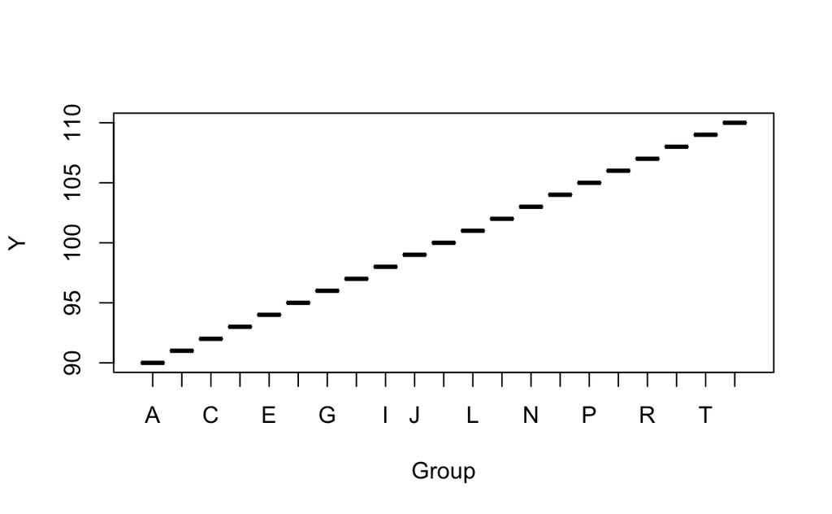

```r
grMeans <- aggregate(Y ~ Group, myData, mean)
plot(grMeans)
```

## 1.1 Model with estimated hyper-parameter

1. Fit model described on the diagram:

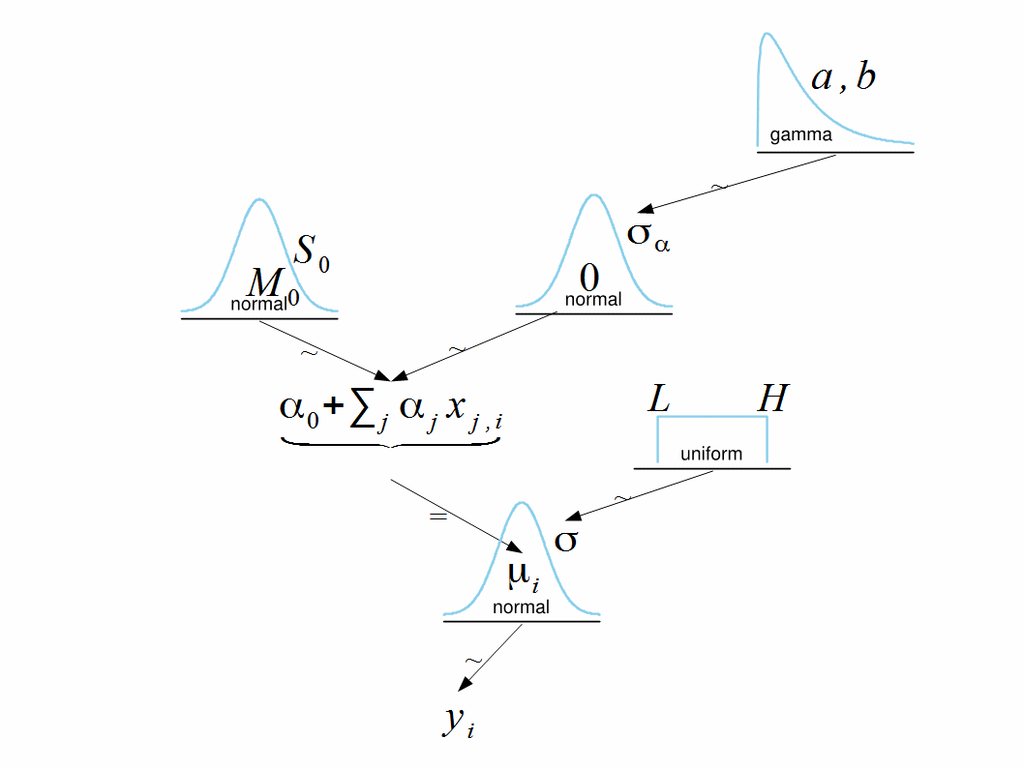

```r
dataList <- list(
  Ntotal = nrow(myData),
  x = as.integer(myData$Group),
  y = myData$Y,
  NxLvl = nlevels(myData$Group),
  agammaShRa = unlist(gammaShRaFromModeSD(
    mode = sd(myData$Y) / 2,
    sd = 2 * sd(myData$Y)
  ))
)

dataList
```

```
## $Ntotal
## [1] 84
##
## $x
##  [1]  1  1  1  1  2  2  2  2  3  3  3  3  4  4  4  4  5  5  5  5  6  6  6
## [24]  6  7  7  7  7  8  8  8  8  9  9  9  9 10 10 10 10 11 11 11 11 12 12
## [47] 12 12 13 13 13 13 14 14 14 14 15 15 15 15 16 16 16 16 17 17 17 17 18
## [70] 18 18 18 19 19 19 19 20 20 20 20 21 21 21 21
##
## $y
##  [1]  93.20414  99.96977  76.21717  90.60892  94.99472  76.45071  99.16353
##  [8]  93.39105  96.15686 103.87791  81.42537  86.53986  82.86390  86.72200
## [15] 104.60814  97.80597 102.64649  95.89177  79.61682  97.84493 103.95923
## [22]  92.05445  82.17039 101.81594  86.92310  93.48558  93.30720 110.28413
## [29]  98.09680 101.25536 105.86442  82.78342  84.55970  97.88813 101.06695
## [36] 108.48521  96.72853 113.30648  90.00387  95.96113 110.82588  99.06048
## [43] 103.21303  86.90061 110.28024  95.31744 108.55835  89.84397 103.84557
## [50]  99.94076 114.19672  90.01695 103.33837  89.08507 112.44333 107.13323
## [57]  90.24786 107.80617 113.81708 104.12890  96.50064 105.71661  98.96762
## [64] 118.81513  97.12274 120.22803 104.81495 101.83428 109.49826 119.90477
## [71]  97.22496 101.37202 109.86143  95.62810 106.61310 119.89737  95.33290
## [78] 118.48985 113.77454 108.40271 108.56689 100.35678 124.01200 107.06433
##
## $NxLvl
## [1] 21
##
## $agammaShRa
##      shape       rate
## 1.28319555 0.05327875
```

Recenter coefficients so that they add up to 0.

```stan
data {
    int<lower=1> Ntotal;
    int<lower=2> NxLvl;
    int<lower=1, upper=NxLvl> x[Ntotal];
    real<lower=0> agammaShRa[2];
    real y[Ntotal];
}
transformed data {
    real meanY;
    real sdY;
    meanY = mean(y);
    sdY = sd(y);
}
parameters {
    real a0;
    real<lower=0> aSigma;
    vector[NxLvl] a;
    real<lower=0> ySigma;
}
model {
    a0 ~ normal(meanY, 5 * sdY);
    aSigma ~ gamma(agammaShRa[1], agammaShRa[2]);
    a ~ normal(0, aSigma);
    ySigma ~ uniform(sdY / 100, sdY * 10);
    for (i in 1:Ntotal) {
        y[i] ~ normal(a0 + a[x[i]], ySigma);
    }
}
generated quantities {
    // Convert a0, a[] to sum-to-zero b0, b[]:
    real b0;
    vector[NxLvl] b;
    b0 = a0 + mean(a);
    b = a - mean(a);
}
```

```r
fit_hyper_params <- sampling(
  model_hyper_parameter,
  data = dataList,
  pars = c("b0", "b", "aSigma", "ySigma"),
  iter = 10000,
  chains = 4,
  cores = 4
)
```

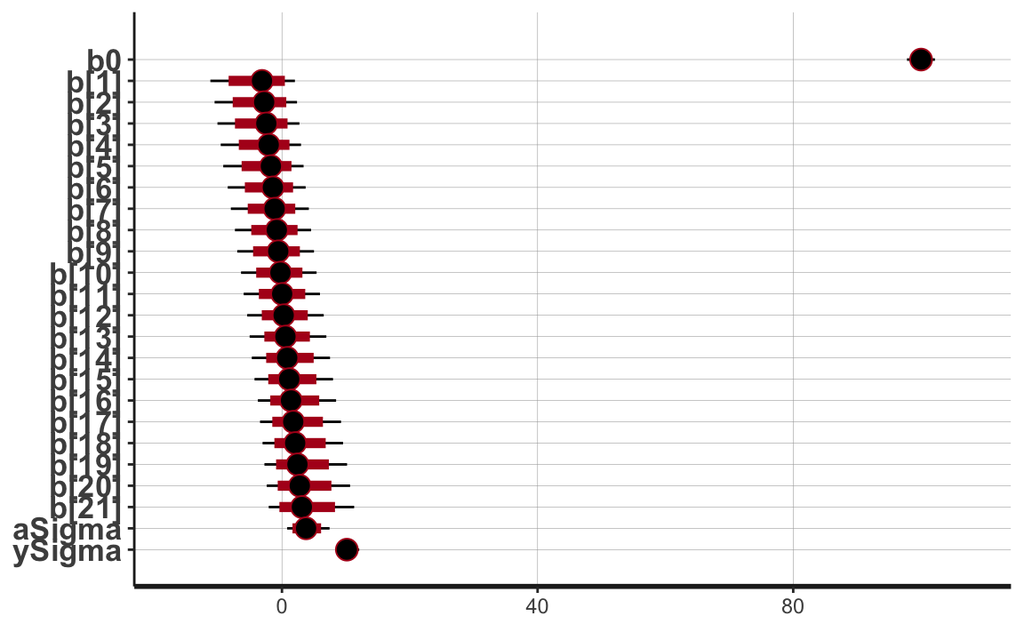

```r
plot(fit_hyper_params, pars = c("b0", "b", "aSigma", "ySigma"))
```

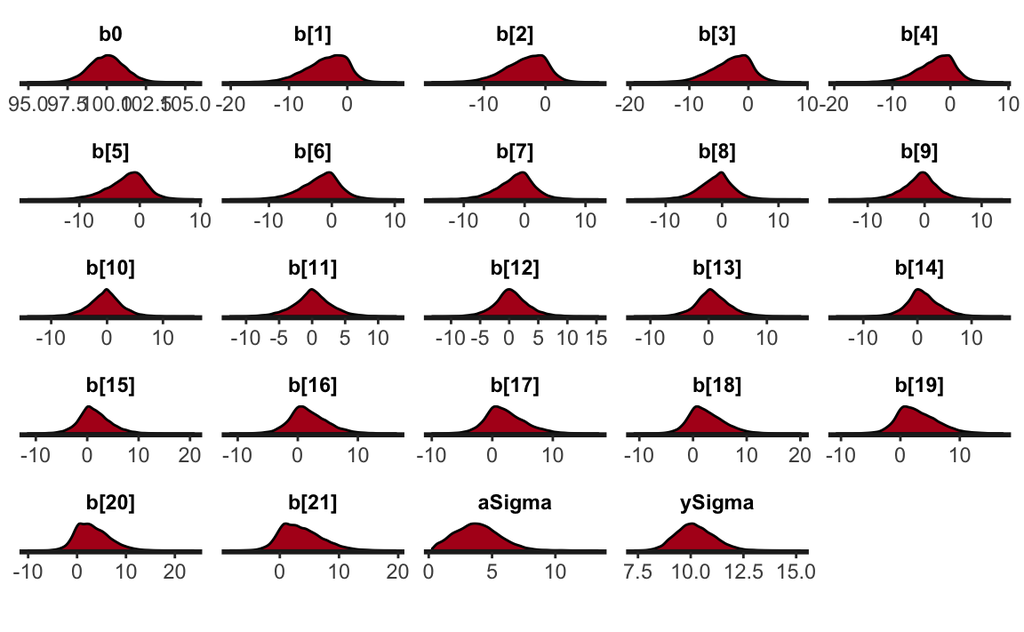

```r
stan_dens(fit_hyper_params, pars = c("b0", "b", "aSigma", "ySigma"))
```

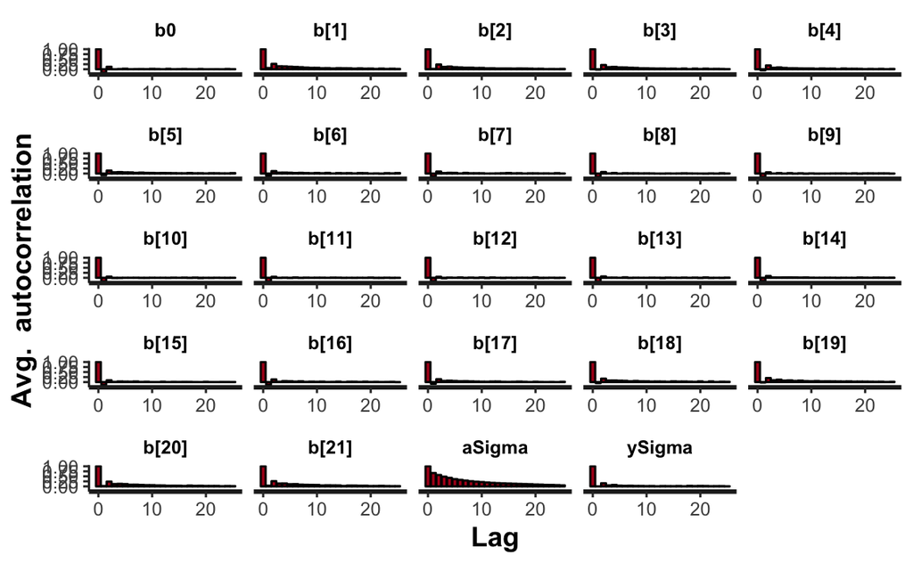

```r
stan_ac(fit_hyper_params, pars = c("b0", "b", "aSigma", "ySigma"))
```

```r
fit_ext_hype <- rstan::extract(fit_hyper_params)

colnames(fit_ext_hype$b) <- myData$Group %>% unique()
fit_ext_hype$b %>% head()
```

```
##
## iterations          A          B           C           D           E
##       [1,] -6.6838012 -0.3173151 -8.49767582 -2.98896393 -6.93238589
##       [2,] -5.2484390  0.3595407 -6.60716586 -2.36966515 -5.47607494
##       [3,] -0.7061743  0.2635873  0.63344644  0.09331086 -0.40704648
##       [4,]  0.1170877 -4.6683935  2.30093650  1.67047252  1.46584481
##       [5,] -1.0248336  1.1242956 -3.38329387 -1.72848568 -2.59755318
##       [6,] -5.9921642 -1.2029441  0.04415009  0.23790264 -0.05368176
##
## iterations          F          G          H           I         J
##       [1,] -2.4084781 -4.9306539  0.4506681 -0.05838076 -3.860779
##       [2,]  3.7818973  2.4860079  0.6832635 -0.69825183 -0.911423
##       [3,]  0.4612156  0.6547501 -0.4750447 -0.73814762 -1.108629
##       [4,] -2.0219479 -1.6610229 -1.9818421 -2.72579588 -1.013581
##       [5,] -3.7876702 -0.6268543 -0.7305019  3.93308858 -3.631466
```

[output cut: 25 more lines]

```r
dim(fit_ext_hype$b)
```

```
## [1] 20000    21
```

Set up the following contrasts:

- U vs. A
- M vs. A
- G vs. A

```r
contrast_u_a <- fit_ext_hype$b[, "U"] - fit_ext_hype$b[, "A"]
contrast_m_a <- fit_ext_hype$b[, "M"] - fit_ext_hype$b[, "A"]
contrast_g_a <- fit_ext_hype$b[, "G"] - fit_ext_hype$b[, "A"]

contrasts <- data.frame(contrast_u_a, contrast_m_a, contrast_g_a)

u <- fit_ext_hype$b[, "U"] + fit_ext_hype$b0
m <- fit_ext_hype$b[, "M"] + fit_ext_hype$b0
a <- fit_ext_hype$b[, "A"] + fit_ext_hype$b0
g <- fit_ext_hype$b[, "G"] + fit_ext_hype$b0

u_density <- density(u)
m_density <- density(m)
a_density <- density(a)
g_density <- density(g)

(hdiContrast_u_a <- hdi(contrast_u_a))
```

```
##     lower     upper
## -2.631979 18.348329
## attr(,"credMass")
## [1] 0.95
```

```r
(hdiContrast_m_a <- hdi(contrast_m_a))
```

```
##     lower     upper
## -4.185096 14.261722
## attr(,"credMass")
## [1] 0.95
```

```r
(hdiContrast_g_a <- hdi(contrast_g_a))
```

```
##     lower     upper
## -5.863747 11.414990
## attr(,"credMass")
## [1] 0.95
```

```r
(sd_contrast_u_a <- sd(hdiContrast_u_a))
```

```
## [1] 14.83532
```

```r
(sd_contrast_m_a <- sd(hdiContrast_m_a))
```

```
## [1] 13.04387
```

```r
(sd_contrast_g_a <- sd(hdiContrast_g_a))
```

```
## [1] 12.21791
```

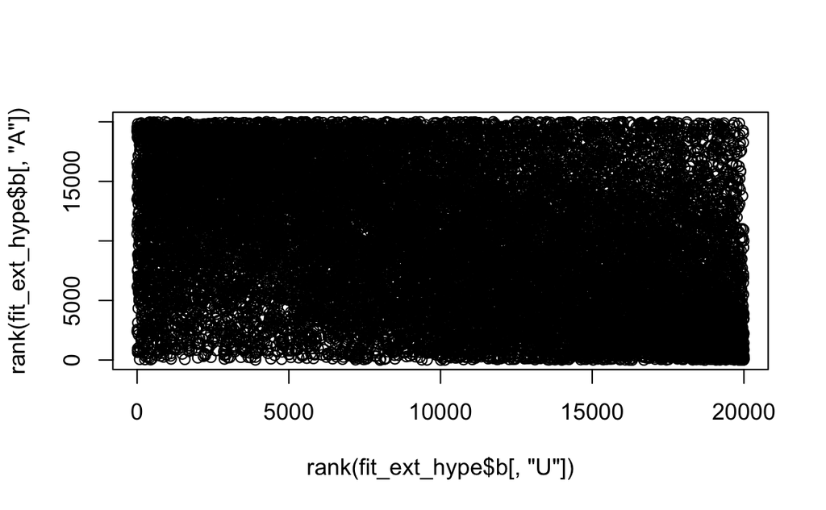

```r
plot(rank(fit_ext_hype$b[, "U"]), rank(fit_ext_hype$b[, "A"]))
```

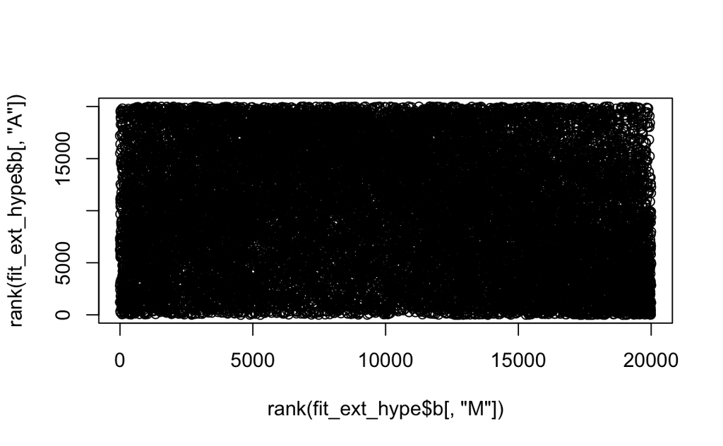

```r
plot(rank(fit_ext_hype$b[, "M"]), rank(fit_ext_hype$b[, "A"]))
```

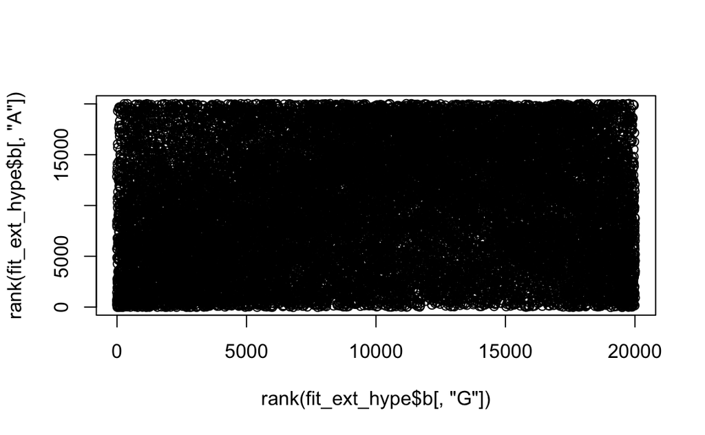

```r
plot(rank(fit_ext_hype$b[, "G"]), rank(fit_ext_hype$b[, "A"]))
```

2. Do any of these contrasts suggest significant differences between the groups? The groups are not significantly different as the contrasts include zero:

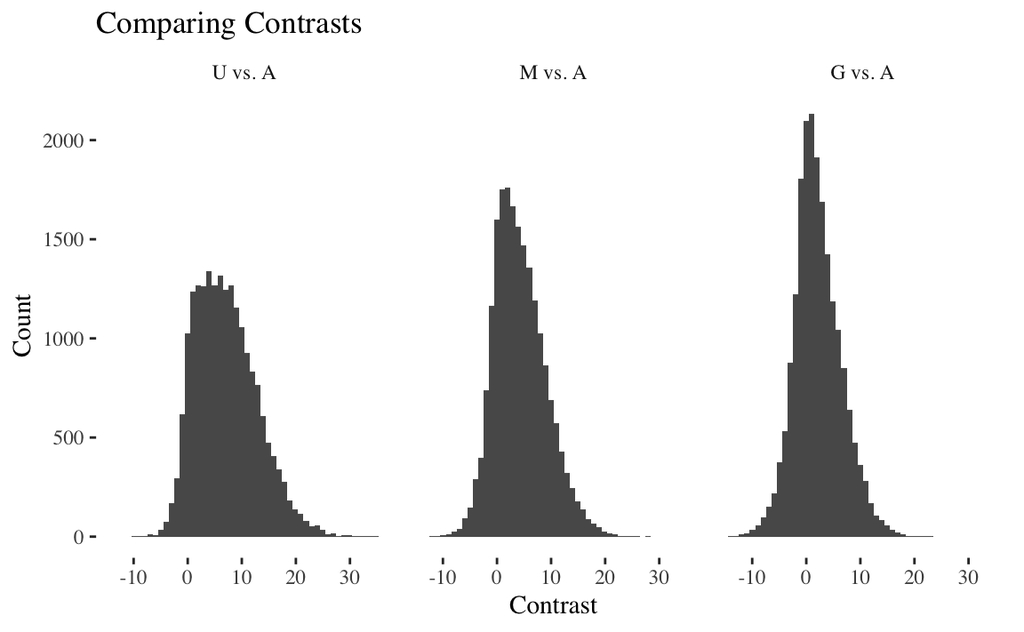

```r
facet_labels <- c(contrast_u_a = "U vs. A",
      contrast_m_a = "M vs. A",
      contrast_g_a = "G vs. A")

contrast_data <- contrasts %>%
  gather(key = "contrast_type", value = "contrast") %>%
  mutate(contrast_type = factor(contrast_type, levels = c("contrast_u_a", "contrast_m_a", "contrast_g_a")))

ggplot(contrast_data, aes(contrast), color = "skyblue") +
  geom_histogram(bins = 50) +
  facet_wrap(vars(contrast_type), labeller = labeller(contrast_type = facet_labels)) +
  labs(title = "Comparing Contrasts",
       x = "Contrast",
       y = "Count")
```

Additionally, the densities overlap significantly:

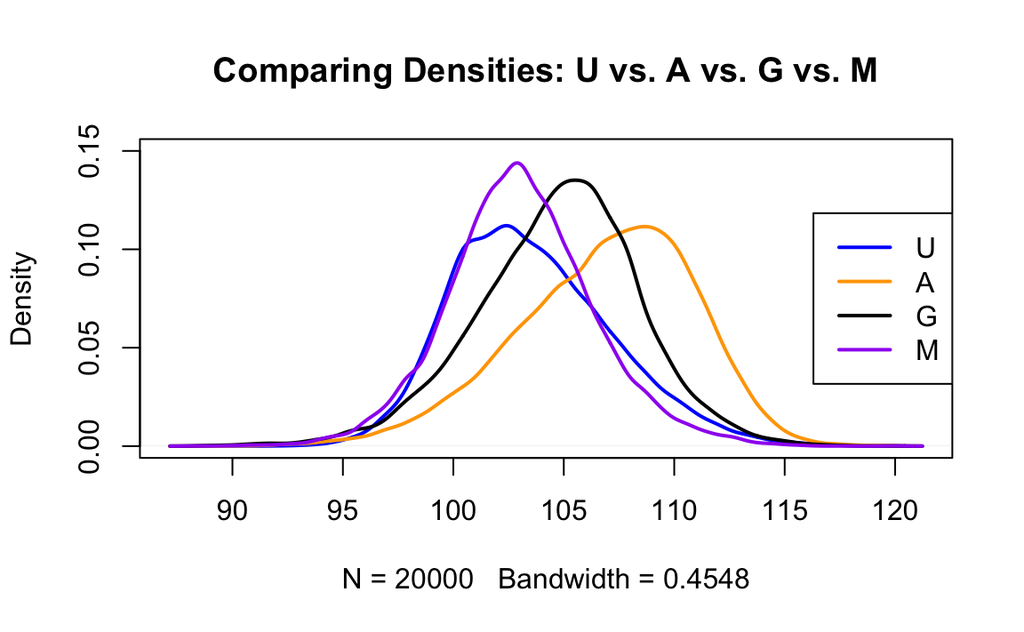

```r
plot(
  u_density,
  ylim = c(0, .15),
  lwd = 2,
  main = "Comparing Densities: U vs. A vs. G vs. M",
  col = "blue"
)
lines(u_density$x, a_density$y, lwd = 2, col = "orange")
lines(u_density$x, g_density$y, lwd = 2, col = "black")
lines(u_density$x, m_density$y, lwd = 2, col = "purple")
legend(
  "right",
  legend = c("U", "A", "G", "M"),
  col = c("blue", "orange", "black", "purple"),
  lty = 1,
  lwd = 2
)
```

3. For each pair what is the estimated contrast? Compare estimated contrasts with the corresponding group mean differences.

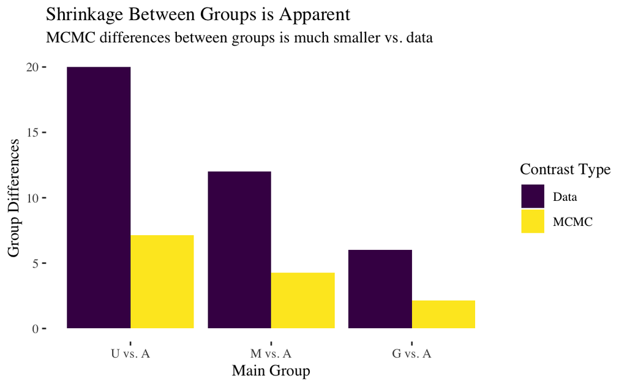

```r
data_difference <- myData %>%
  group_by(Group) %>%
  summarise_all(mean) %>%
  set_names(c("Group", "mean_y")) %>%
  filter(Group %in% c("U", "A", "G", "M")) %>%
  spread(Group, mean_y) %>%
  mutate(group_diff_u_a = U - A,
         group_diff_m_a = M - A,
         group_diff_g_a = G - A) %>%
  select(group_diff_u_a:group_diff_g_a) %>%
  gather(key = group, value = group_difference) %>%
  mutate(main_group = factor(case_when(
    group == "group_diff_u_a" ~ "u_a",
    group == "group_diff_m_a" ~ "m_a",
    group == "group_diff_g_a" ~ "g_a"
  ), levels = c("u_a", "m_a", "g_a"), labels = c("U vs. A", "M vs. A", "G vs. A"))) %>%
  mutate(type = "data")

mcmc_difference <- contrast_data %>%
  group_by(contrast_type) %>%
  summarise_all(mean) %>%
  set_names(c("group", "group_difference")) %>%
  mutate(main_group = factor(case_when(
    group == "contrast_u_a" ~ "u_a",
    group == "contrast_m_a" ~ "m_a",
    group == "contrast_g_a" ~ "g_a"
  ), levels = c("u_a", "m_a", "g_a"), labels = c("U vs. A", "M vs. A", "G vs. A")),
  type = "mcmc",
  group = as.character(group))

data_difference %>%
  bind_rows(mcmc_difference) %>%
  ggplot(aes(main_group, group_difference, fill = type)) +
  geom_col(position = "dodge") +
  scale_fill_viridis_d(name = "Contrast Type", labels = c("Data", "MCMC")) +
  labs(title = "Shrinkage Between Groups is Apparent",
       subtitle = "MCMC differences between groups is much smaller vs. data",
       x = "Main Group",
       y = "Group Differences")
```

## 1.2 Model without hyper-parameter

1. Modify the model so that $\sigma\alpha$ is not estimated from the data. Fit this model.

```stan
data {
    int<lower=1> Ntotal;
    int<lower=2> NxLvl;
    int<lower=1, upper=NxLvl> x[Ntotal];
    real y[Ntotal];
}
transformed data {
    real meanY;
    real sdY;
    meanY = mean(y);
    sdY = sd(y);
}
parameters {
    real a0;
    vector[NxLvl] a;
    real<lower=0> ySigma;
}
model {
    a0 ~ normal(meanY, 5 * sdY);
    a ~ normal(0, 100);
    ySigma ~ uniform(sdY / 100, sdY * 10);
    for (i in 1:Ntotal) {
        y[i] ~ normal(a0 + a[x[i]], ySigma);
    }
}
generated quantities {
    // Convert a0, a[] to sum-to-zero b0, b[]:
    real b0;
    vector[NxLvl] b;
    b0 = a0 + mean(a);
    b = a - mean(a);
}
```

```r
fit_no_hyper_params <- sampling(
  model_no_hyper_parameter,
  data = dataList,
  pars = c("b0", "b", "ySigma"),
  iter = 10000,
  chains = 4,
  cores = 4
)
```

1. Answer the questions 1, 2 and 3 from previous section. Explain the differences.

Set up the following contrasts:

- U vs. A
- M vs. A
- G vs. A

```r
fit_ext_no_hype <- rstan::extract(fit_no_hyper_params)

colnames(fit_ext_no_hype$b) <- myData$Group %>% unique()
fit_ext_no_hype$b %>% head()
```

```
##
## iterations          A          B          C          D           E
##       [1,] -11.280288 -10.217852  -3.336955 -13.719287  -7.3590324
##       [2,] -11.708391  -6.371394   7.006623  -9.183051  -0.7081712
##       [3,]   1.250548 -16.683798 -11.143041  -5.051355  -3.3745679
##       [4,] -15.945355  -7.816545  -6.132277  -2.375969 -16.8630755
##       [5,]  -8.597518 -16.228732  -6.447566 -14.361813  -7.4610621
##       [6,]  -7.941431  -5.668582  -6.293087   2.101109  -5.9504414
##
## iterations          F          G          H          I          J
##       [1,]  -1.115893 -8.4052669  -7.820528  0.5096181  -4.162139
##       [2,]  -7.333506 -0.4211452  -6.886051 -1.6271900 -12.135723
##       [3,] -10.929929 -4.4459944 -12.491452  7.5686370  -5.721753
##       [4,]  -9.379407 -1.2223074  -4.325403 -4.5951118 -11.464527
##       [5,]  -4.007156 -3.0112438  -1.489591 -2.8368459   2.676244
```

[output cut: 17 more lines]

```r
dim(fit_ext_no_hype$b)
```

```
## [1] 20000    21
```

```r
contrast_u_a <- fit_ext_no_hype$b[, "U"] - fit_ext_no_hype$b[, "A"]
contrast_m_a <- fit_ext_no_hype$b[, "M"] - fit_ext_no_hype$b[, "A"]
contrast_g_a <- fit_ext_no_hype$b[, "G"] - fit_ext_no_hype$b[, "A"]

contrasts <- data.frame(contrast_u_a, contrast_m_a, contrast_g_a)

u <- fit_ext_no_hype$b[, "U"] + fit_ext_no_hype$b0
m <- fit_ext_no_hype$b[, "M"] + fit_ext_no_hype$b0
a <- fit_ext_no_hype$b[, "A"] + fit_ext_no_hype$b0
g <- fit_ext_no_hype$b[, "G"] + fit_ext_no_hype$b0

u_density <- density(u)
m_density <- density(m)
a_density <- density(a)
g_density <- density(g)

(hdiContrast_u_a <- hdi(contrast_u_a))
```

```
##     lower     upper
##  5.578717 33.745558
## attr(,"credMass")
## [1] 0.95
```

```r
(hdiContrast_m_a <- hdi(contrast_m_a))
```

```
##     lower     upper
## -2.422001 25.820360
## attr(,"credMass")
## [1] 0.95
```

```r
(hdiContrast_g_a <- hdi(contrast_g_a))
```

```
##     lower     upper
## -7.765431 20.389284
## attr(,"credMass")
## [1] 0.95
```

```r
(sd_contrast_u_a <- sd(hdiContrast_u_a))
```

```
## [1] 19.91696
```

```r
(sd_contrast_m_a <- sd(hdiContrast_m_a))
```

```
## [1] 19.97037
```

```r
(sd_contrast_g_a <- sd(hdiContrast_g_a))
```

```
## [1] 19.90839
```

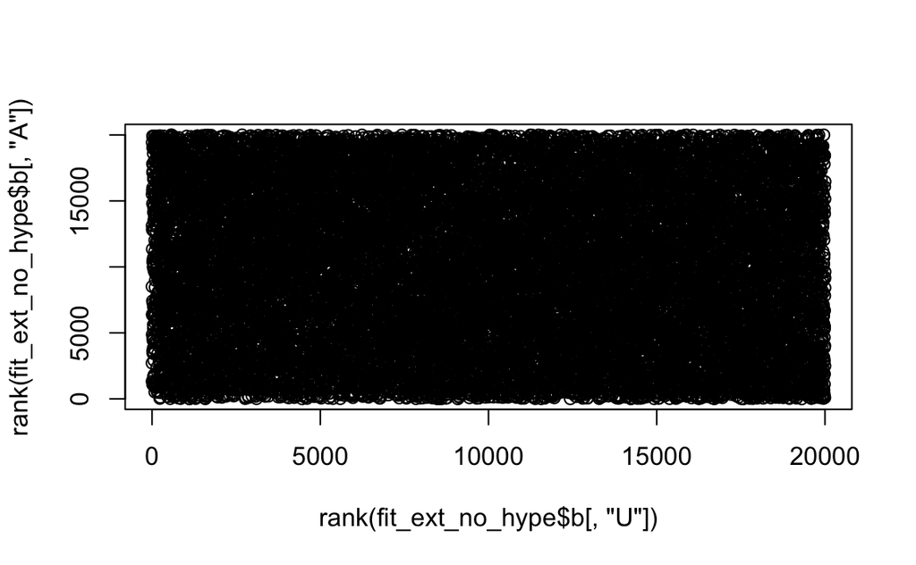

```r
plot(rank(fit_ext_no_hype$b[, "U"]), rank(fit_ext_no_hype$b[, "A"]))
```

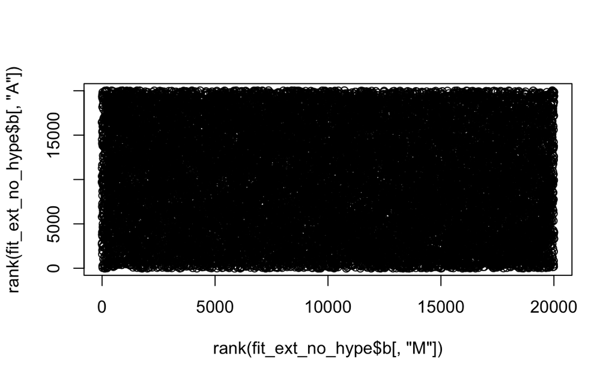

```r
plot(rank(fit_ext_no_hype$b[, "M"]), rank(fit_ext_no_hype$b[, "A"]))
```

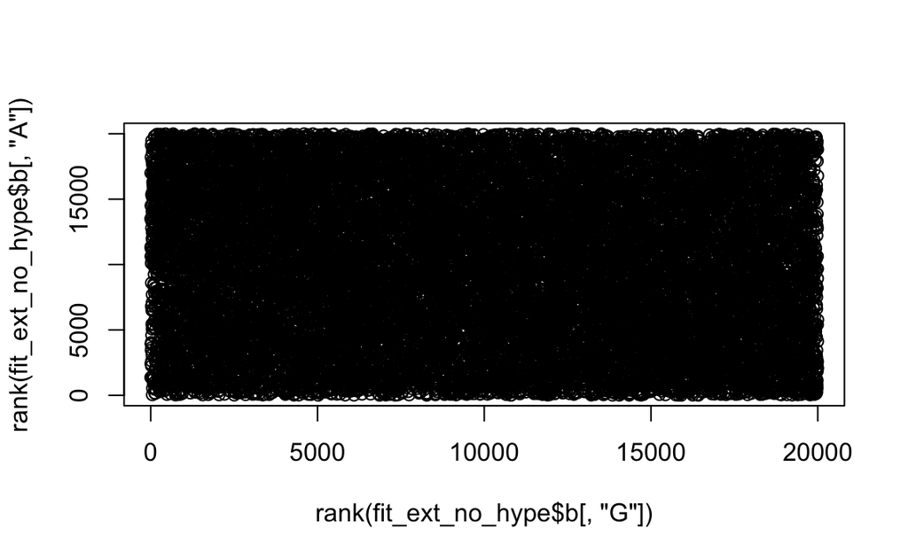

```r
plot(rank(fit_ext_no_hype$b[, "G"]), rank(fit_ext_no_hype$b[, "A"]))
```

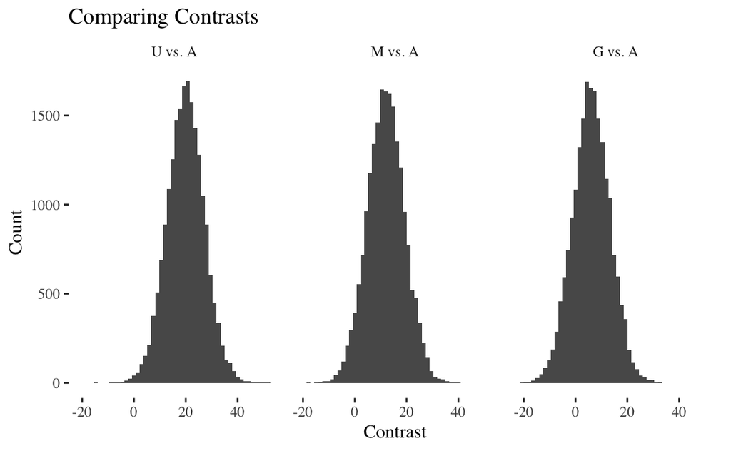

```r
facet_labels <- c(contrast_u_a = "U vs. A",
      contrast_m_a = "M vs. A",
      contrast_g_a = "G vs. A")

contrast_data <- contrasts %>%
  gather(key = "contrast_type", value = "contrast") %>%
  mutate(contrast_type = factor(contrast_type, levels = c("contrast_u_a", "contrast_m_a", "contrast_g_a")))

ggplot(contrast_data, aes(contrast), color = "skyblue") +
  geom_histogram(bins = 50) +
  facet_wrap(vars(contrast_type), labeller = labeller(contrast_type = facet_labels)) +
  labs(title = "Comparing Contrasts",
       x = "Contrast",
       y = "Count")
```

Additionally, the densities overlap nearly completely. Note the densities for `model_no_hyper_parameter` overlap due to the exclusion of the hyper prior. The upshot is all the groups get a the same $\sigma$.

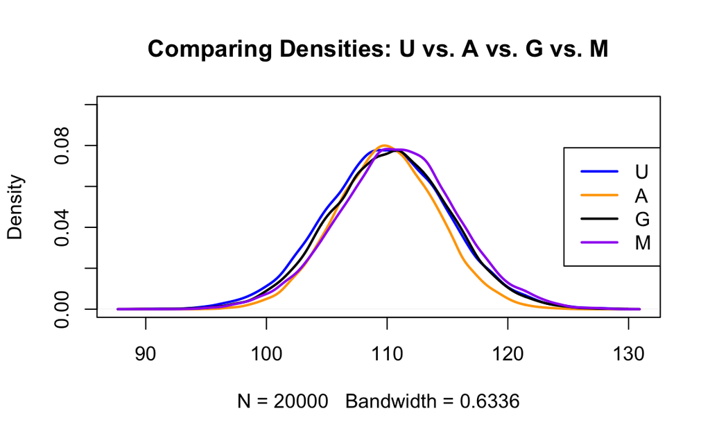

```r
plot(
  u_density,
  ylim = c(0, .10),
  lwd = 2,
  main = "Comparing Densities: U vs. A vs. G vs. M",
  col = "blue"
)
lines(u_density$x, a_density$y, lwd = 2, col = "orange")
lines(u_density$x, g_density$y, lwd = 2, col = "black")
lines(u_density$x, m_density$y, lwd = 2, col = "purple")
legend(
  "right",
  legend = c("U", "A", "G", "M"),
  col = c("blue", "orange", "black", "purple"),
  lty = 1,
  lwd = 2
)
```

3. For each pair what is the estimated contrast? Compare estimated contrasts with the corresponding group mean differences.

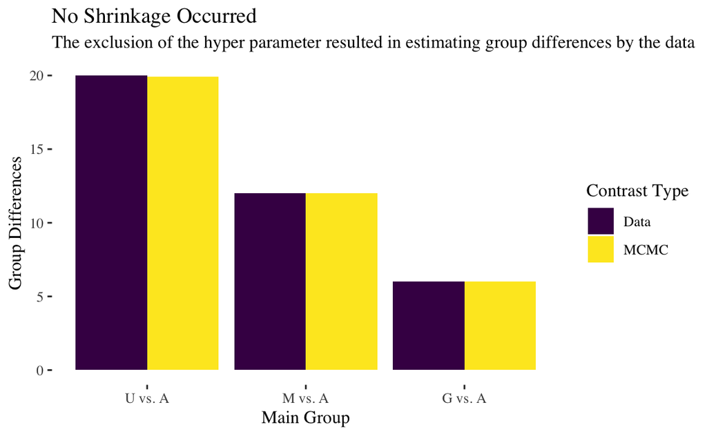

```r
data_difference <- myData %>%
  group_by(Group) %>%
  summarise_all(mean) %>%
  set_names(c("Group", "mean_y")) %>%
  filter(Group %in% c("U", "A", "G", "M")) %>%
  spread(Group, mean_y) %>%
  mutate(group_diff_u_a = U - A,
         group_diff_m_a = M - A,
         group_diff_g_a = G - A) %>%
  select(group_diff_u_a:group_diff_g_a) %>%
  gather(key = group, value = group_difference) %>%
  mutate(main_group = factor(case_when(
    group == "group_diff_u_a" ~ "u_a",
    group == "group_diff_m_a" ~ "m_a",
    group == "group_diff_g_a" ~ "g_a"
  ), levels = c("u_a", "m_a", "g_a"), labels = c("U vs. A", "M vs. A", "G vs. A"))) %>%
  mutate(type = "data")

mcmc_difference <- contrast_data %>%
  group_by(contrast_type) %>%
  summarise_all(mean) %>%
  set_names(c("group", "group_difference")) %>%
  mutate(main_group = factor(case_when(
    group == "contrast_u_a" ~ "u_a",
    group == "contrast_m_a" ~ "m_a",
    group == "contrast_g_a" ~ "g_a"
  ), levels = c("u_a", "m_a", "g_a"), labels = c("U vs. A", "M vs. A", "G vs. A")),
  type = "mcmc",
  group = as.character(group))

data_difference %>%
  bind_rows(mcmc_difference) %>%
  ggplot(aes(main_group, group_difference, fill = type)) +
  geom_col(position = "dodge") +
  scale_fill_viridis_d(name = "Contrast Type", labels = c("Data", "MCMC")) +
  labs(title = "No Shrinkage Occurred",
       subtitle = "The exclusion of the hyper parameter resulted in estimating group differences by the data",
       x = "Main Group",
       y = "Group Differences")
```

Eliminating the hyper parameter $\sigma\alpha$ resulted in MCMC estimating the actual group differences in the data, as seen in the plot above. This essentially resulted in a fixed effects model, while including the hypter parameter introduces random effects that focus on the population rather than the difference between the groups.